# Experimental treatment with edaravone in a mouse model of spinocerebellar ataxia 1

Analysis of motor deficit on rotarod

Author

Martina Sucha, Simona Benediktova, Filip Tichanek, Jan Jedlicka, Stepan Kapl, Dana Jelinkova, Zdenka Purkartova, Jan Tuma, Jitka Kuncova, Jan Cendelin

This page shows R code for the study [Sucha et al.](https://www.mdpi.com/1422-0067/24/13/10689) (2023, *International Journal of Molecular Science*).

**Citation**:

> Sucha M, Benediktova S, Tichanek F, Jedlicka J, Kapl S, Jelinkova D, Purkartova Z, Tuma J, Kuncova J, Cendelin J. Experimental Treatment with Edaravone in a Mouse Model of Spinocerebellar Ataxia 1. International Journal of Molecular Sciences. 2023; 24(13):10689. https://doi.org/10.3390/ijms241310689

[GitHub page](https://github.com/filip-tichanek/edaravonSCA1): https://github.com/filip-tichanek/edaravonSCA1

# 1 Upload of packages

```r
rm(list = ls())

suppressWarnings(suppressMessages( {
library(brms)
library(beeswarm)
library(vioplot)
library(glmmTMB)
library(car)
library(cowplot)
library(ggplot2)
library(tidyverse)
library(bayesplot)
library(gtsummary)
library(vegan)
library(knitr)
library(ggplot2)
  } ) )
```

# 2 Data upload and wrangling

```r
load("source_data/myEnvironment.RData")

## defining new variables
rotarod$group <- interaction(rotarod$treatment, rotarod$genotype)
rotarod$group <- factor(rotarod$group,levels=c('ctrl.wt','eda.wt','ctrl.sca','eda.sca'))
rotarod$sex_num <- ifelse(rotarod$sex == "f", -0.5, 0.5)

rotarod$group_sex <- interaction(rotarod$treatment, rotarod$genotype, rotarod$sex)
rotarod$group_sex <- factor(rotarod$group_sex, levels=c('ctrl.wt.f','ctrl.wt.m',
                                                  'eda.wt.f','eda.wt.m',
                                                  'ctrl.sca.f','ctrl.sca.m',
                                                  'eda.sca.f','eda.sca.m'))

## subject as factor
rotarod$id <- as.factor(rotarod$id)


## order of all roatrod tests
rotarod$order <- (rotarod$day-1) * 4 + rotarod$session
rotarod$order2 <- ifelse(rotarod$pre_post == 'pre', rotarod$order, rotarod$order+12)

## data summary
summary(rotarod)
```

```
       id       treatment  genotype  sex          day       session
 7      :  24   ctrl:960   sca:960   f:936   Min.   :1   Min.   :1.00
 9      :  24   eda :960   wt :960   m:984   1st Qu.:1   1st Qu.:1.75
 11     :  24                                Median :2   Median :2.50
 12     :  24                                Mean   :2   Mean   :2.50
 13     :  24                                3rd Qu.:3   3rd Qu.:3.25
 14     :  24                                Max.   :3   Max.   :4.00
 (Other):1776
  rot_latency     pre_post        group        sex_num             group_sex
 Min.   :  2.30   post:960   ctrl.wt :480   Min.   :-0.5000   ctrl.wt.m :264
 1st Qu.: 94.97   pre :960   eda.wt  :480   1st Qu.:-0.5000   eda.wt.f  :240
 Median :126.90              ctrl.sca:480   Median : 0.5000   eda.wt.m  :240
 Mean   :127.79              eda.sca :480   Mean   : 0.0125   ctrl.sca.f:240
 3rd Qu.:157.60                             3rd Qu.: 0.5000   ctrl.sca.m:240
 Max.   :299.20                             Max.   : 0.5000   eda.sca.f :240
                                                              (Other)   :456
     order           order2
 Min.   : 1.00   Min.   : 1.00
 1st Qu.: 3.75   1st Qu.: 6.75
 Median : 6.50   Median :12.50
 Mean   : 6.50   Mean   :12.50
 3rd Qu.: 9.25   3rd Qu.:18.25
 Max.   :12.00   Max.   :24.00
```

Sub-setting pre-treatment and post-treatment rotarod data and data aggregation.

We will create 3 aggregated datasets, each with different pre-treatment rotarod latency (*preTreat RotLat*) variable. The reason is that our previous observations suggested that the genotype-related difference is less pronounced for the first 1-2 rotarod session(s) and do not predict later rotarod well. Models will be fitted using all three datasets and the model with the best predictive accuracy (as estimated via *leave-one-out cross-validation* - LOO-CV) will be used

```r
## subseting post-treatment dataset
rot_post <- subset(rotarod, rotarod$pre_post == 'post')

## pre-treatment rotarod
rot_pre3 <- subset(rotarod, rotarod$pre_post == 'pre'& rotarod$day >2)
rot_pre23 <- subset(rotarod,rotarod$pre_post == 'pre'& rotarod$day >1)
rot_pre <- subset(rotarod, rotarod$pre_post == 'pre')

## aggregated data sets. Each has different definition of pre-treatment rotarod:

### mean from all pre-treatment rotarod runs
rot_pre_agg <- rot_pre %>%
  group_by(id) %>%
  summarise(mean_lat = mean(rot_latency))

### mean from 2nd and 3rd day
rot_pre_agg_23 <- rot_pre23 %>%
  group_by(id) %>%
  summarise(mean_lat = mean(rot_latency))

### mean from 3rd rotarod day only
rot_pre_agg_3 <- rot_pre3 %>%
  group_by(id) %>%
  summarise(mean_lat = mean(rot_latency))

## joining new variable to post-treatment rotarod data
rot_post_co <- rot_post %>%
  left_join(rot_pre_agg, by ='id') %>%
  left_join(rot_pre_agg_23, by ='id') %>%
  left_join(rot_pre_agg_3, by ='id')

## centering the variables 'day' and 'session'
rot_post_co$day_cen <- rot_post_co$day-2
rot_post_co$session_cen <- rot_post_co$session -2.5

summary(rot_post_co)
```

```
       id      treatment  genotype  sex          day       session
 7      : 12   ctrl:480   sca:480   f:468   Min.   :1   Min.   :1.00
 9      : 12   eda :480   wt :480   m:492   1st Qu.:1   1st Qu.:1.75
 11     : 12                                Median :2   Median :2.50
 12     : 12                                Mean   :2   Mean   :2.50
 13     : 12                                3rd Qu.:3   3rd Qu.:3.25
 14     : 12                                Max.   :3   Max.   :4.00
 (Other):888
  rot_latency     pre_post        group        sex_num             group_sex
 Min.   : 16.10   post:960   ctrl.wt :240   Min.   :-0.5000   ctrl.wt.m :132
 1st Qu.: 93.75   pre :  0   eda.wt  :240   1st Qu.:-0.5000   eda.wt.f  :120
 Median :125.75              ctrl.sca:240   Median : 0.5000   eda.wt.m  :120
 Mean   :126.67              eda.sca :240   Mean   : 0.0125   ctrl.sca.f:120
 3rd Qu.:155.03                             3rd Qu.: 0.5000   ctrl.sca.m:120
 Max.   :291.20                             Max.   : 0.5000   eda.sca.f :120
                                                              (Other)   :228
     order           order2        mean_lat.x       mean_lat.y
 Min.   : 1.00   Min.   :13.00   Min.   : 55.98   Min.   : 55.67
 1st Qu.: 3.75   1st Qu.:15.75   1st Qu.:108.61   1st Qu.:117.49
 Median : 6.50   Median :18.50   Median :127.36   Median :136.45
 Mean   : 6.50   Mean   :18.50   Mean   :128.90   Mean   :140.28
 3rd Qu.: 9.25   3rd Qu.:21.25   3rd Qu.:147.82   3rd Qu.:166.12
 Max.   :12.00   Max.   :24.00   Max.   :195.66   Max.   :218.11

    mean_lat        day_cen    session_cen
 Min.   : 60.2   Min.   :-1   Min.   :-1.50
 1st Qu.:121.4   1st Qu.:-1   1st Qu.:-0.75
 Median :141.0   Median : 0   Median : 0.00
 Mean   :146.2   Mean   : 0   Mean   : 0.00
 3rd Qu.:173.2   3rd Qu.: 1   3rd Qu.: 0.75
 Max.   :255.6   Max.   : 1   Max.   : 1.50
```

New variables *mean_lat.x*, *mean_lat.y*, *mean_lat* indicate pre-treatment rotarod latency (*preTreat RotLat*) used as covariate in models to adjuste for baseline performance

- 1. *mean_lat.x*: average latency from all pre-treatment measurements
- 2. *mean_lat.y*: latency averaged from the days 2 and 3
- 3. *mean_lat* latency averaged from the 3rd day

# 3 Data exploration

Figure showing individual trajectories or rotarod (all 24 sessions, blue vertical line shows transition from *pre-treatment* to *post-treatment*)

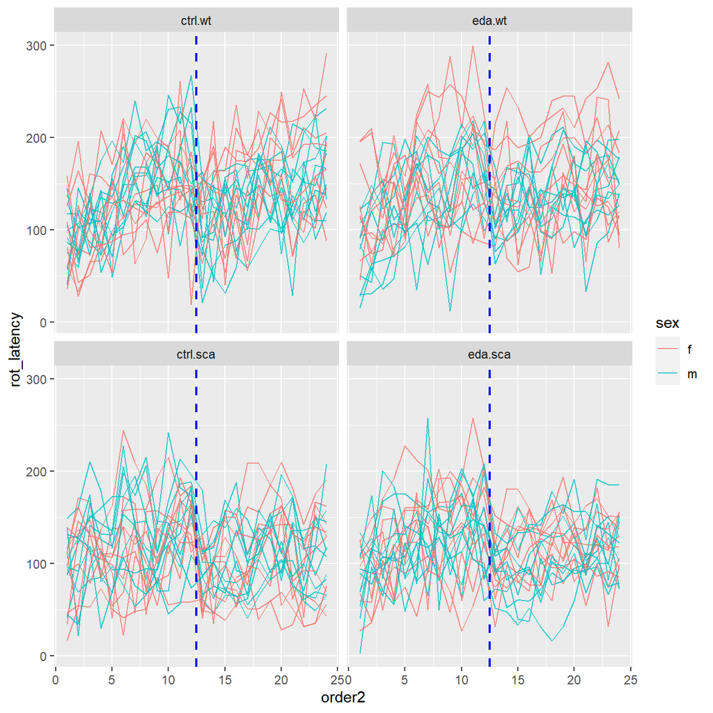

```r
rotarod %>% ggplot(aes(x=order2, y=rot_latency, by=id, col=sex)) +
  geom_line(alpha=0.8) +
  geom_vline(xintercept = 12.5,
                color = "blue", linewidth=0.8, linetype= 'dashed') +
  facet_wrap(~group)
```

Sex does not exhibit consistent effect, or only minor specifically in WT group. We will ignore the *sex* throughout the analysis

Figure showing data distribution per group

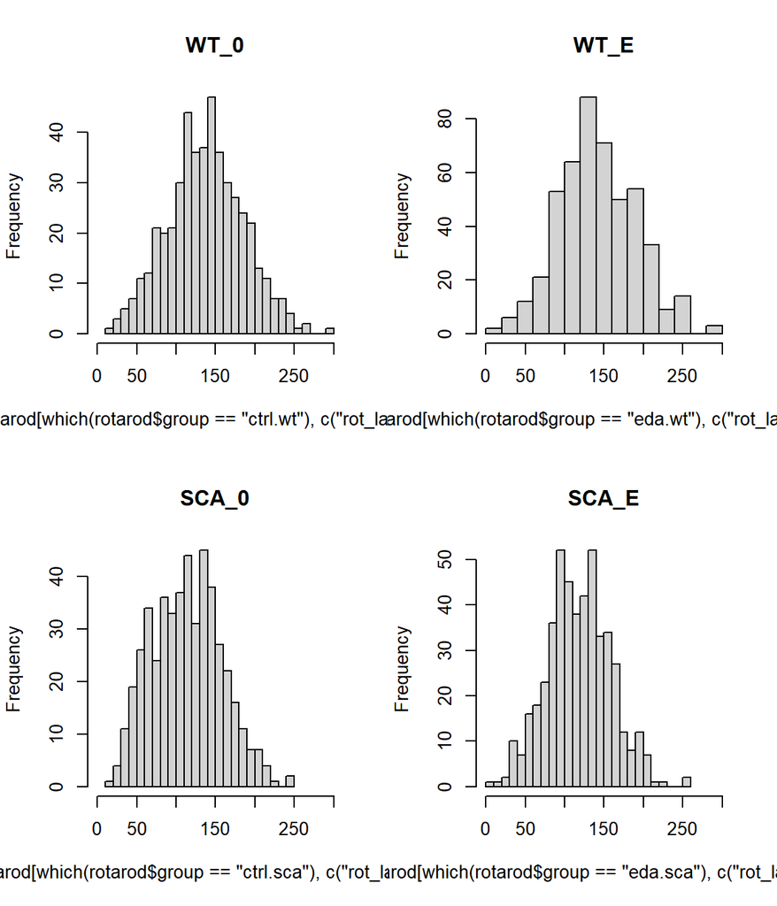

```r
par(mfrow=c(2,2))
hist(rotarod[which(rotarod$group == 'ctrl.wt'),c('rot_latency')], 20, main="WT_0", xlim=c(0,300))
hist(rotarod[which(rotarod$group == 'eda.wt'),c('rot_latency')], 20, main="WT_E", xlim=c(0,300))
hist(rotarod[which(rotarod$group == 'ctrl.sca'),c('rot_latency')], 20,
     main="SCA_0", xlim=c(0,300))
hist(rotarod[which(rotarod$group == 'eda.sca'),c('rot_latency')], 20, main="SCA_E", xlim=c(0,300))
```

Distributions seem more or less symmetric. I do not see marks of heteroscedasticity (width of distribution seems similar across groups, similar magnitude of changes in low- and high-performing individuals on the previous plot of individual trajectories).

# 4 Modelling

As rotarod latency in non-negative, and right tail-distribution is expected, gamma likelihood may be the first choice. On the other hand, the values of latency is restricted as the rotarod increases the speed; the latency is thus strongly restricted, resulting in normal-like distribution.

Also data exploration suggest that Gaussian likelihood distribution may be reasonable choice here. We will fit both and look on *posterior predictive check* (PPC) to choose between them.

Firstly, we will select likelihood used, with models including pre-treatment roator latency averaged over all pre-treatment rotarod measurements (*mean_lat.x*).

## 4.1 Prior specification

First, we look at data summary statistics and estimate from previous publication [Tichanek et al.](https://www.nature.com/articles/s41598-020-62308-0)

```r
## changing reference group
rot_post_co$group<-relevel(rot_post_co$group,ref='ctrl.sca')

## wrangling data from Tichanek et al.
young_scirep <- young_scirep %>% mutate(
  rotarod_latency = mean(grepl('rotarod', young_scirep)))

young_scirep$rot_lat <- rowMeans(young_scirep[
  ,which(grepl("rotarod", colnames(young_scirep)))])

## prior for genotype effect, using Gaussian likelihood
mprio_norm <- glmmTMB(rot_lat~genotype, data = young_scirep)
summary(mprio_norm)
```

```
 Family: gaussian  ( identity )
Formula:          rot_lat ~ genotype
Data: young_scirep

     AIC      BIC   logLik deviance df.resid
   569.5    575.6   -281.8    563.5       52


Dispersion estimate for gaussian family (sigma^2): 1.65e+03

Conditional model:
            Estimate Std. Error z value Pr(>|z|)
(Intercept)  134.771      7.416  18.174   <2e-16 ***
genotypew     24.259     10.999   2.206   0.0274 *
---
Signif. codes:  0 '***' 0.001 '**' 0.01 '*' 0.05 '.' 0.1 ' ' 1
```

```r
prios(mprio_norm)
```

```
 Estimate
 2.701332 32.337246
```

```r
## prior for genotype effect with Gamma likelihood
mprio_norm <- glmmTMB(rot_lat~genotype, data = young_scirep,family=Gamma(link="log"))
summary(mprio_norm)
```

```
 Family: Gamma  ( log )
Formula:          rot_lat ~ genotype
Data: young_scirep

     AIC      BIC   logLik deviance df.resid
   567.2    573.2   -280.6    561.2       52


Dispersion estimate for Gamma family (sigma^2): 0.079

Conditional model:
            Estimate Std. Error z value Pr(>|z|)
(Intercept)  4.90358    0.05133   95.53   <2e-16 ***
genotypew    0.16552    0.07613    2.17   0.0297 *
---
Signif. codes:  0 '***' 0.001 '**' 0.01 '*' 0.05 '.' 0.1 ' ' 1
```

```r
prios(mprio_norm)
```

```
  Estimate
0.01629459 0.22383596
```

```r
## summary statistics
mean(rot_post_co$rot_latency)
```

```
[1] 126.674
```

```r
mean(rot_post_co[rot_post_co$genotype == 'sca', c('rot_latency')])
```

```
[1] 109.2742
```

```r
sd(rot_post_co$rot_latency) *c(5, 2, 1.2)
```

```
[1] 229.65135  91.86054  55.11632
```

```r
sd(rot_post_co[rot_post_co$genotype == 'sca', c('rot_latency')])*c(5, 2, 1.2)
```

```
[1] 191.03904  76.41562  45.84937
```

```r
mean(log(rot_post_co$rot_latency))
```

```
[1] 4.765482
```

```r
mean(log(rot_post_co[rot_post_co$genotype == 'sca', c('rot_latency')]))
```

```
[1] 4.621306
```

```r
sd(log(rot_post_co$rot_latency))*c(5)
```

```
[1] 2.07183
```

## 4.2 Setting priors, preTreat RotLat: all days

```r
## priors for Gaussian model
prior01 <- c(set_prior("student_t(3, 127, 229)", class = "b", coef = "Intercept"),
             set_prior("normal(0,92)", class = "b", coef = "groupctrl.wt"),
             set_prior("normal(0,92)", class = "b", coef = "groupeda.wt"),
             set_prior("normal(0,46)"  , class = "b", coef = "groupeda.sca"),
             set_prior("normal(10,20)", class = "b", coef = "day_cen"),
             set_prior("normal(0,20)", class = "b", coef = "session_cen"),
             set_prior("normal(0,2)", class = "b", coef = "session_cen:day_cen"),
             set_prior("normal(0.5,2)", class = "b", coef = "mean_lat.x"))

## prior for Gamma (log-linked) model
prior02 <- c(set_prior("student_t(3, 4.8, 2.1)", class = "b", coef = "Intercept"),
             set_prior("normal(0,2)", class = "b", coef = "groupctrl.wt"),
             set_prior("normal(0,2)", class = "b", coef = "groupeda.wt"),
             set_prior("normal(0,1.2)", class = "b", coef = "groupeda.sca"),
             set_prior("normal(0.2,0.5)", class = "b", coef = "day_cen"),
             set_prior("normal(0,0.5)", class = "b", coef = "session_cen"),
             set_prior("normal(0,0.2)", class = "b", coef = "session_cen:day_cen"),
             set_prior("normal(0.5,1)", class = "b", coef = "mean_lat.x"))
```

## 4.3 Fitting and diagnsotics, preTreat RotLat: all days

```r
## fitting gaussian model
model1 <- run_model(
          brm(rot_latency ~ 0 + Intercept + mean_lat.x + session_cen +
                day_cen + session_cen:day_cen + group + (1|id),
              family=gaussian(),
              data = rot_post_co,
              prior= prior01,
              save_pars = save_pars(all = TRUE),
              iter=8000, warmup=2000,chains=2,cores=1,seed=17,
              control = list(adapt_delta = 0.99, max_treedepth = 15)),
              'output/brm/model1', reuse = TRUE)

### fitting gamma model
model2 <- run_model(
          brm(rot_latency ~ 0 + Intercept + mean_lat.x + session_cen +
                day_cen + session_cen:day_cen + group + (1|id),
              family=Gamma(link = 'log'),
              data = rot_post_co,
              prior= prior02,
              save_pars = save_pars(all = TRUE),
              iter=8000, warmup=2000,chains=2,cores=1,seed=17,
              control = list(adapt_delta = 0.99, max_treedepth = 15)),
              'output/brm/model2', reuse = TRUE)

## models summary
summary(model1)
```

```
 Family: gaussian
  Links: mu = identity; sigma = identity
Formula: rot_latency ~ 0 + Intercept + mean_lat.x + session_cen + day_cen + session_cen:day_cen + group + (1 | id)
   Data: rot_post_co (Number of observations: 960)
  Draws: 2 chains, each with iter = 8000; warmup = 2000; thin = 1;
         total post-warmup draws = 12000

Group-Level Effects:
~id (Number of levels: 80)
              Estimate Est.Error l-95% CI u-95% CI Rhat Bulk_ESS Tail_ESS
sd(Intercept)    24.22      2.29    20.09    29.10 1.00     2140     4087

Population-Level Effects:
                    Estimate Est.Error l-95% CI u-95% CI Rhat Bulk_ESS Tail_ESS
Intercept              39.03     14.23    10.97    66.87 1.00     1272     2805
mean_lat.x              0.56      0.11     0.35     0.77 1.00     1358     2896
session_cen             5.90      0.89     4.15     7.63 1.00    12064     9673
day_cen                 8.99      1.23     6.56    11.37 1.00    10391     8646
groupctrl.wt           29.56      8.21    13.30    46.05 1.00     1211     2165
groupeda.wt            27.82      8.16    11.59    43.94 1.00     1536     3203
groupeda.sca            3.29      7.95   -12.34    18.69 1.00     1313     2785
session_cen:day_cen    -0.26      0.96    -2.13     1.63 1.00    11634     9794

Family Specific Parameters:
      Estimate Est.Error l-95% CI u-95% CI Rhat Bulk_ESS Tail_ESS
sigma    30.88      0.73    29.48    32.33 1.00    10860     9755

Draws were sampled using sampling(NUTS). For each parameter, Bulk_ESS
and Tail_ESS are effective sample size measures, and Rhat is the potential
scale reduction factor on split chains (at convergence, Rhat = 1).
```

```r
summary(model2)
```

```
 Family: gamma
  Links: mu = log; shape = identity
Formula: rot_latency ~ 0 + Intercept + mean_lat.x + session_cen + day_cen + session_cen:day_cen + group + (1 | id)
   Data: rot_post_co (Number of observations: 960)
  Draws: 2 chains, each with iter = 8000; warmup = 2000; thin = 1;
         total post-warmup draws = 12000

Group-Level Effects:
~id (Number of levels: 80)
              Estimate Est.Error l-95% CI u-95% CI Rhat Bulk_ESS Tail_ESS
sd(Intercept)     0.20      0.02     0.17     0.24 1.00     3088     5140

Population-Level Effects:
                    Estimate Est.Error l-95% CI u-95% CI Rhat Bulk_ESS Tail_ESS
Intercept               4.11      0.12     3.88     4.35 1.00     3155     4839
mean_lat.x              0.00      0.00     0.00     0.01 1.00     3220     4962
session_cen             0.05      0.01     0.03     0.06 1.00    17402     8648
day_cen                 0.07      0.01     0.05     0.09 1.00    16963     8730
groupctrl.wt            0.26      0.07     0.12     0.40 1.00     2524     4237
groupeda.wt             0.25      0.07     0.11     0.38 1.00     2755     4614
groupeda.sca            0.05      0.07    -0.08     0.19 1.00     2617     4652
session_cen:day_cen    -0.01      0.01    -0.02     0.01 1.00    16026     8456

Family Specific Parameters:
      Estimate Est.Error l-95% CI u-95% CI Rhat Bulk_ESS Tail_ESS
shape    12.82      0.61    11.66    14.04 1.00    14064     8030

Draws were sampled using sampling(NUTS). For each parameter, Bulk_ESS
and Tail_ESS are effective sample size measures, and Rhat is the potential
scale reduction factor on split chains (at convergence, Rhat = 1).
```

Convergence is OK; both models lead to the same conclusions and similar estimates

## 4.4 PPC, preTreat RotLat: all days

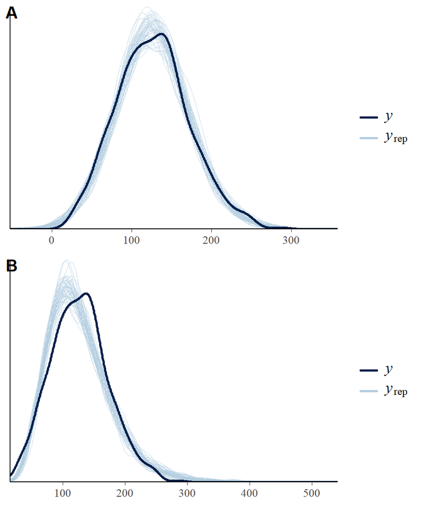

```r
pla<-pp_check(model1,type='dens_overlay',ndraws = 50)
plb<-pp_check(model2,type='dens_overlay',ndraws = 50)
plot_grid(pla, plb, labels=c("A", "B"), ncol = 1, nrow = 2)
```

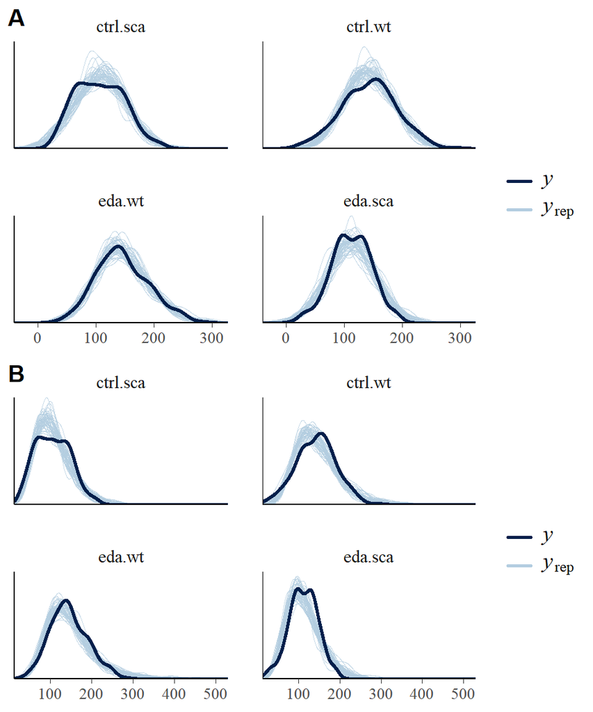

```r
pla<-pp_check(model1,type='dens_overlay_grouped',ndraws = 50,group='group')
plb<-pp_check(model2,type='dens_overlay_grouped',ndraws = 50,group='group')
plot_grid(pla, plb, labels=c("A", "B"), ncol = 1, nrow = 2)
```

```r
pla<-pp_check(model1,type='scatter_avg')
```

```
Using all posterior draws for ppc type 'scatter_avg' by default.
```

```r
plb<-pp_check(model2,type='scatter_avg')
```

```
Using all posterior draws for ppc type 'scatter_avg' by default.
```

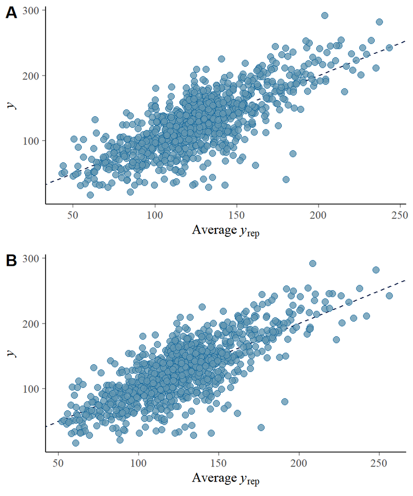

```r
plot_grid(pla, plb, labels=c("A", "B"), ncol = 1, nrow = 2)
```

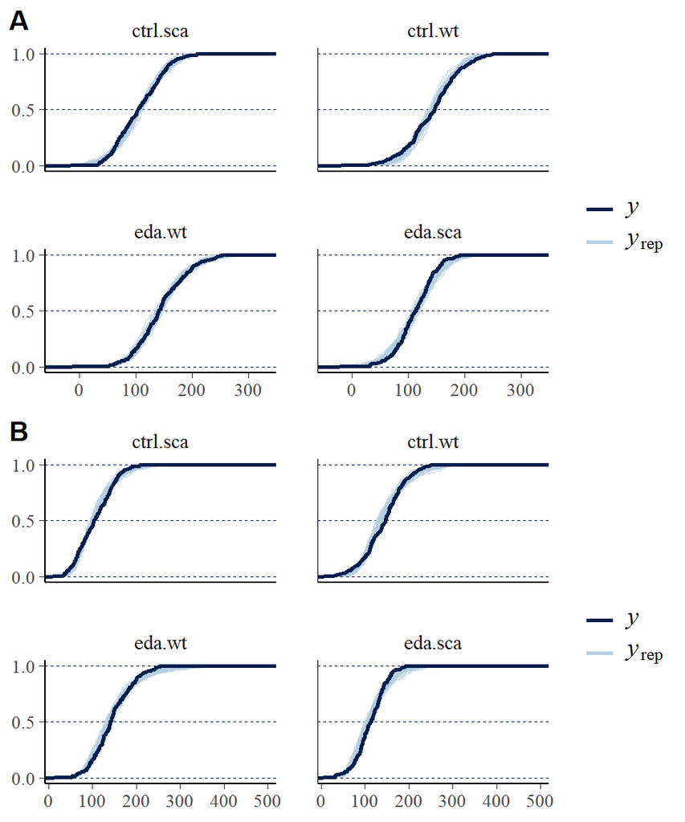

```r
pla<-pp_check(model1,type='ecdf_overlay_grouped',ndraws = 50,group='group')
plb<-pp_check(model2,type='ecdf_overlay_grouped',ndraws = 50,group='group')
plot_grid(pla, plb, labels=c("A", "B"), ncol = 1, nrow = 2)
```

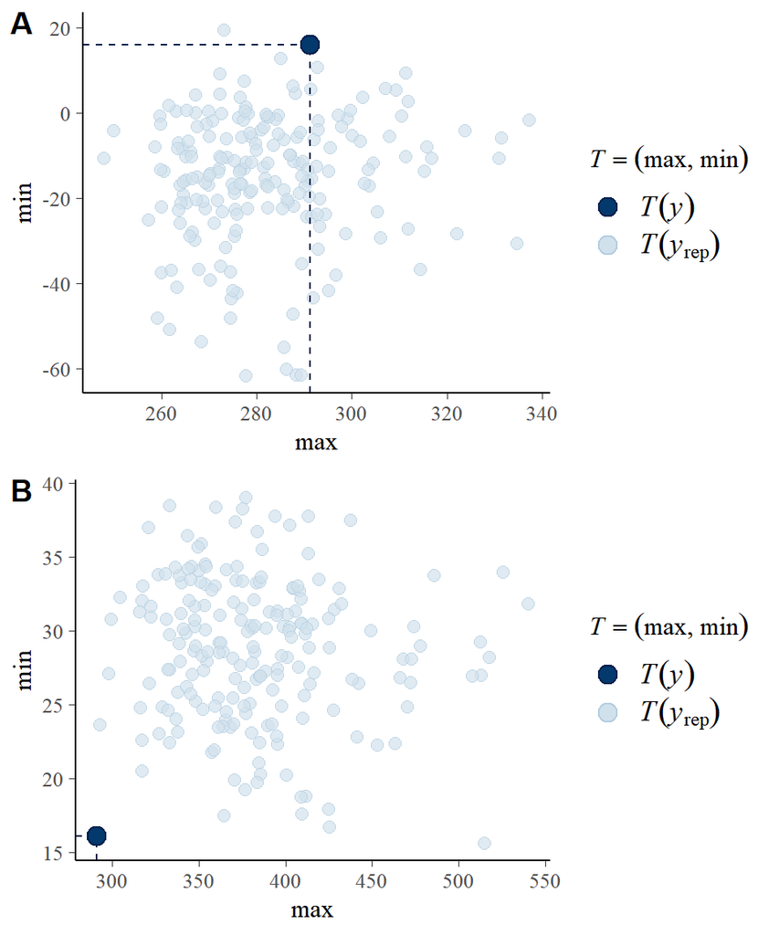

```r
pla<-pp_check(model1,type="stat_2d", stat = c("max", "min"),ndraws=200)
plb<-pp_check(model2,type="stat_2d", stat = c("max", "min"),ndraws=200)
plot_grid(pla, plb, labels=c("A", "B"), ncol = 1, nrow = 2)
```

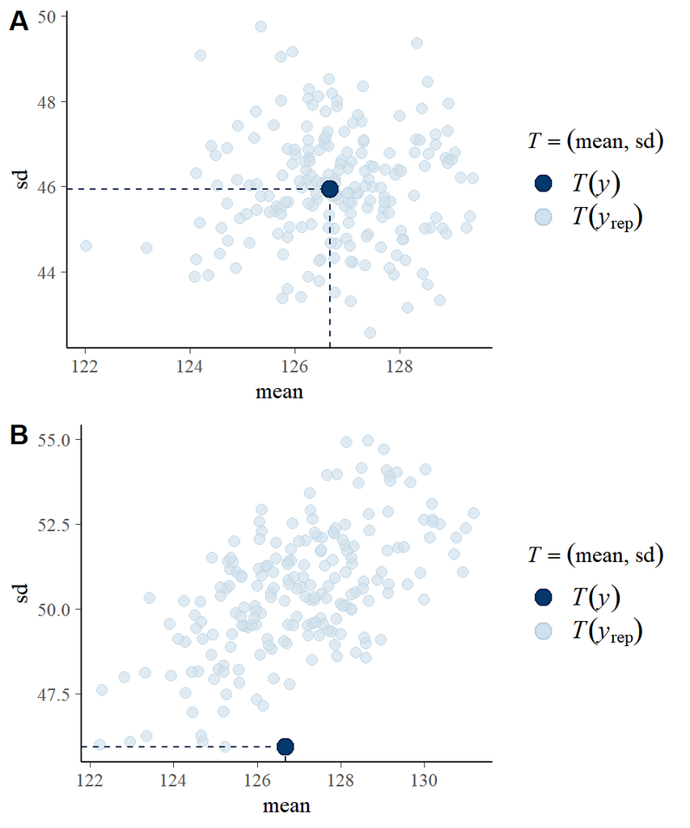

```r
pla<-pp_check(model1,type="stat_2d", stat = c("mean", "sd"),ndraws=200)
plb<-pp_check(model2,type="stat_2d", stat = c("mean", "sd"),ndraws=200)
plot_grid(pla, plb, labels=c("A", "B"), ncol = 1, nrow = 2)
```

```r
### Are there too influential observations?
par(mfrow=c(1,2))
plot(loo(model1));loo(model1)
```

```
Computed from 12000 by 960 log-likelihood matrix

         Estimate   SE
elpd_loo  -4694.3 26.9
p_loo        73.1  4.1
looic      9388.6 53.8
------
Monte Carlo SE of elpd_loo is 0.1.

Pareto k diagnostic values:
                         Count Pct.    Min. n_eff
(-Inf, 0.5]   (good)     959   99.9%   2736
 (0.5, 0.7]   (ok)         1    0.1%   561
   (0.7, 1]   (bad)        0    0.0%   <NA>
   (1, Inf)   (very bad)   0    0.0%   <NA>

All Pareto k estimates are ok (k < 0.7).
See help('pareto-k-diagnostic') for details.
```

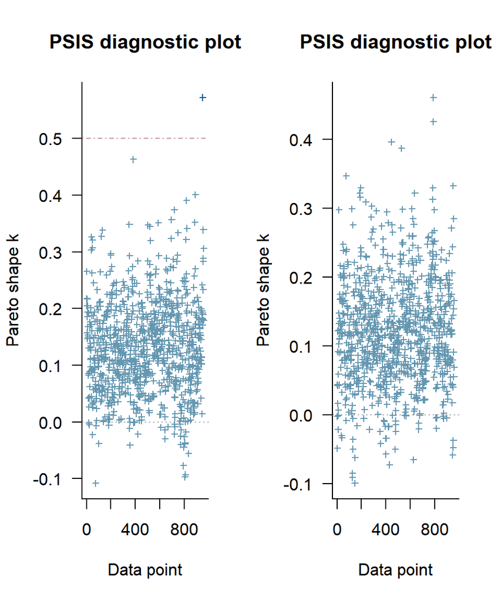

```
Computed from 12000 by 960 log-likelihood matrix

         Estimate   SE
elpd_loo  -4759.1 28.9
p_loo        62.9  3.4
looic      9518.1 57.7
------
Monte Carlo SE of elpd_loo is 0.1.

All Pareto k estimates are good (k < 0.5).
See help('pareto-k-diagnostic') for details.
```

```r
plot(loo(model2));loo(model2)
```

Posterior predictive checks (PPC) shows that Gaussian model fits data clearly better than Gamma model. All models are OK, no pareto value > 0.7, indicating no overly influential observation

Lets to fit two other Gaussian models with different deficnition of pre-treatment rotarod latency

## 4.5 Setting prior for other models

```r
## preTreat RotLat: 3rd day only
prior03 <- c(set_prior("student_t(3, 127, 229)", class = "b", coef = "Intercept"),
             set_prior("normal(0,92)", class = "b", coef = "groupctrl.wt"),
             set_prior("normal(0,92)", class = "b", coef = "groupeda.wt"),
             set_prior("normal(0,46)"  , class = "b", coef = "groupeda.sca"),
             set_prior("normal(10,20)", class = "b", coef = "day_cen"),
             set_prior("normal(0,20)", class = "b", coef = "session_cen"),
             set_prior("normal(0,2)", class = "b", coef = "session_cen:day_cen"),
             set_prior("normal(0.5,2)", class = "b", coef = "mean_lat"))

## preTreat RotLat: 2nd and 3rd day
prior04 <- c(set_prior("student_t(3, 127, 229)", class = "b", coef = "Intercept"),
             set_prior("normal(0,92)", class = "b", coef = "groupctrl.wt"),
             set_prior("normal(0,92)", class = "b", coef = "groupeda.wt"),
             set_prior("normal(0,46)"  , class = "b", coef = "groupeda.sca"),
             set_prior("normal(10,20)", class = "b", coef = "day_cen"),
             set_prior("normal(0,20)", class = "b", coef = "session_cen"),
             set_prior("normal(0,2)", class = "b", coef = "session_cen:day_cen"),
             set_prior("normal(0.5,2)", class = "b", coef = "mean_lat.y"))
```

## 4.6 Fitting and diagnsotics, preTreat RotLat: 3rd (+2nd) days

```r
## preTreat RotLat: 3rd day only
model3 <- run_model(
          brm(rot_latency ~ 0 + Intercept + mean_lat + session_cen +
              day_cen + session_cen:day_cen + group + (1|id),
              family=gaussian(),
              data = rot_post_co,
              prior= prior03,
              save_pars = save_pars(all = TRUE),
              iter=8000, warmup=2000,chains=2,cores=1,seed=17,
              control = list(adapt_delta = 0.99)),
              'output/brm/model3', reuse = TRUE)

## preTreat RotLat: 2nd + 3rd day
model4 <- run_model(
          brm(rot_latency ~ 0 + Intercept + mean_lat.y + session_cen +
              day_cen + session_cen:day_cen + group + (1|id),
              family=gaussian(),
              data = rot_post_co,
              prior= prior04,
              save_pars = save_pars(all = TRUE),
              iter=8000, warmup=2000,chains=2,cores=1,seed=17,
              control = list(adapt_delta = 0.99)),
              'output/brm/model4', reuse = TRUE)

## models summary
summary(model3)
```

```
 Family: gaussian
  Links: mu = identity; sigma = identity
Formula: rot_latency ~ 0 + Intercept + mean_lat + session_cen + day_cen + session_cen:day_cen + group + (1 | id)
   Data: rot_post_co (Number of observations: 960)
  Draws: 2 chains, each with iter = 8000; warmup = 2000; thin = 1;
         total post-warmup draws = 12000

Group-Level Effects:
~id (Number of levels: 80)
              Estimate Est.Error l-95% CI u-95% CI Rhat Bulk_ESS Tail_ESS
sd(Intercept)    25.41      2.35    21.25    30.35 1.00     2368     4856

Population-Level Effects:
                    Estimate Est.Error l-95% CI u-95% CI Rhat Bulk_ESS Tail_ESS
Intercept              57.53     12.68    32.65    82.28 1.00     1533     2830
mean_lat                0.38      0.08     0.21     0.54 1.00     1635     3175
session_cen             5.89      0.90     4.12     7.66 1.00    12401     8102
day_cen                 8.97      1.22     6.56    11.37 1.00    14924     9215
groupctrl.wt           26.77      8.58    10.17    43.81 1.00     1583     3191
groupeda.wt            27.79      8.89    10.47    45.04 1.00     1713     3408
groupeda.sca            2.87      8.39   -13.56    19.45 1.00     1604     3085
session_cen:day_cen    -0.27      0.94    -2.14     1.56 1.00    12862     9054

Family Specific Parameters:
      Estimate Est.Error l-95% CI u-95% CI Rhat Bulk_ESS Tail_ESS
sigma    30.89      0.73    29.50    32.35 1.00    11835     9004

Draws were sampled using sampling(NUTS). For each parameter, Bulk_ESS
and Tail_ESS are effective sample size measures, and Rhat is the potential
scale reduction factor on split chains (at convergence, Rhat = 1).
```

```r
summary(model4)
```

```
 Family: gaussian
  Links: mu = identity; sigma = identity
Formula: rot_latency ~ 0 + Intercept + mean_lat.y + session_cen + day_cen + session_cen:day_cen + group + (1 | id)
   Data: rot_post_co (Number of observations: 960)
  Draws: 2 chains, each with iter = 8000; warmup = 2000; thin = 1;
         total post-warmup draws = 12000

Group-Level Effects:
~id (Number of levels: 80)
              Estimate Est.Error l-95% CI u-95% CI Rhat Bulk_ESS Tail_ESS
sd(Intercept)    24.55      2.31    20.48    29.48 1.00     2335     4617

Population-Level Effects:
                    Estimate Est.Error l-95% CI u-95% CI Rhat Bulk_ESS Tail_ESS
Intercept              47.30     13.27    21.52    73.68 1.00     1657     2816
mean_lat.y              0.47      0.09     0.29     0.65 1.00     1464     3143
session_cen             5.89      0.90     4.13     7.64 1.00    13934     8304
day_cen                 8.96      1.23     6.53    11.38 1.00    12177     8586
groupctrl.wt           25.76      8.42     9.39    42.52 1.00     1587     3152
groupeda.wt            25.71      8.75     8.25    42.69 1.00     1504     2833
groupeda.sca            1.51      8.23   -15.36    17.35 1.00     1433     2399
session_cen:day_cen    -0.26      0.97    -2.18     1.64 1.00    13103     8714

Family Specific Parameters:
      Estimate Est.Error l-95% CI u-95% CI Rhat Bulk_ESS Tail_ESS
sigma    30.91      0.73    29.52    32.39 1.00    10656     8660

Draws were sampled using sampling(NUTS). For each parameter, Bulk_ESS
and Tail_ESS are effective sample size measures, and Rhat is the potential
scale reduction factor on split chains (at convergence, Rhat = 1).
```

All models converged well (Rhat values = 1), ESSs are sufficient

## 4.7 PPC, preTreat RotLat: 3rd (+2nd) days

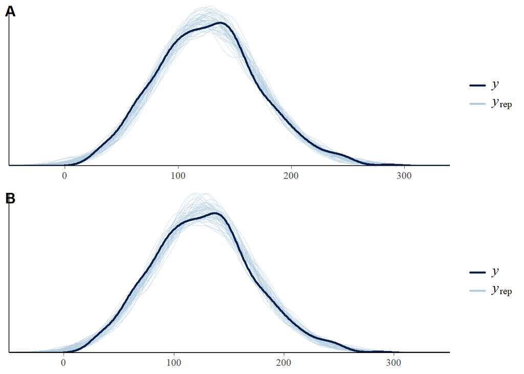

```r
pla<-pp_check(model3,type='dens_overlay',ndraws = 50)
plb<-pp_check(model4,type='dens_overlay',ndraws = 50)
plot_grid(pla, plb, labels=c("A", "B"), ncol = 1, nrow = 2)
```

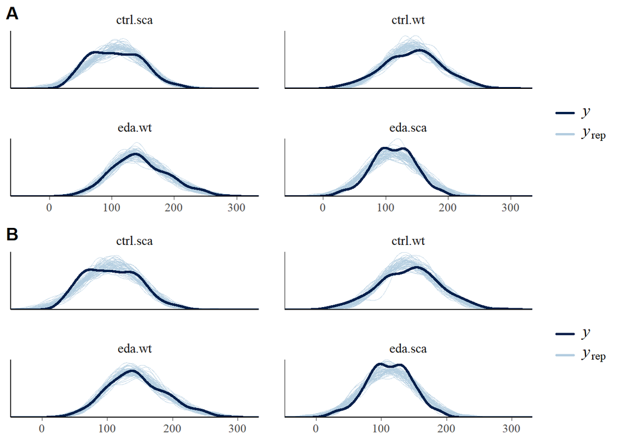

```r
pla<-pp_check(model3,type='dens_overlay_grouped',ndraws = 50,group='group')
plb<-pp_check(model4,type='dens_overlay_grouped',ndraws = 50,group='group')
plot_grid(pla, plb, labels=c("A", "B"), ncol = 1, nrow = 2)
```

```r
pla<-pp_check(model3,type='scatter_avg')
```

```
Using all posterior draws for ppc type 'scatter_avg' by default.
```

```r
plb<-pp_check(model4,type='scatter_avg')
```

```
Using all posterior draws for ppc type 'scatter_avg' by default.
```

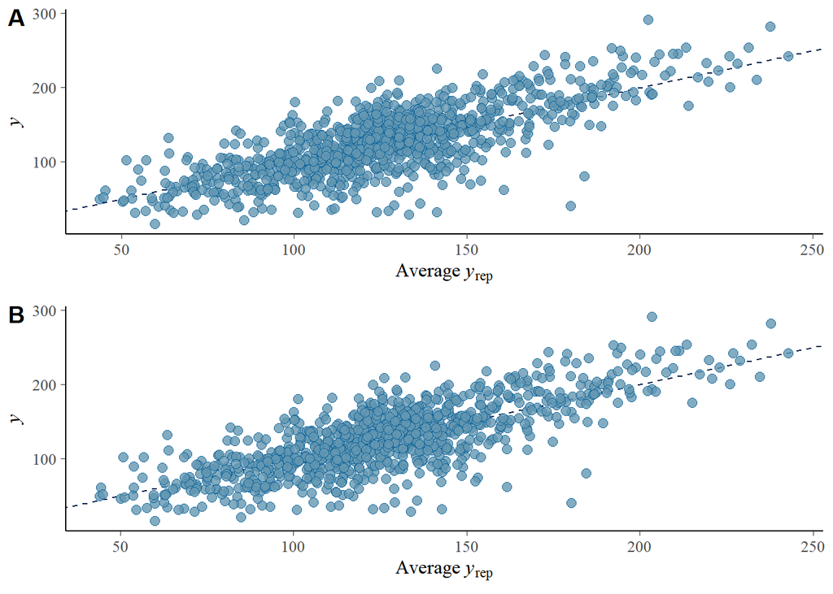

```r
plot_grid(pla, plb, labels=c("A", "B"), ncol = 1, nrow = 2)
```

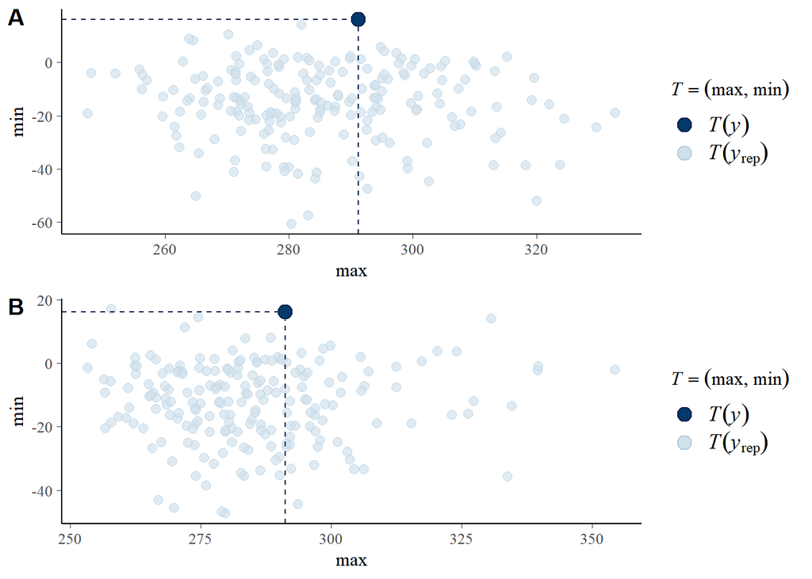

```r
pla<-pp_check(model3,type="stat_2d", stat = c("max", "min"),ndraws=200)
plb<-pp_check(model4,type="stat_2d", stat = c("max", "min"),ndraws=200)
plot_grid(pla, plb, labels=c("A", "B"), ncol = 1, nrow = 2)
```

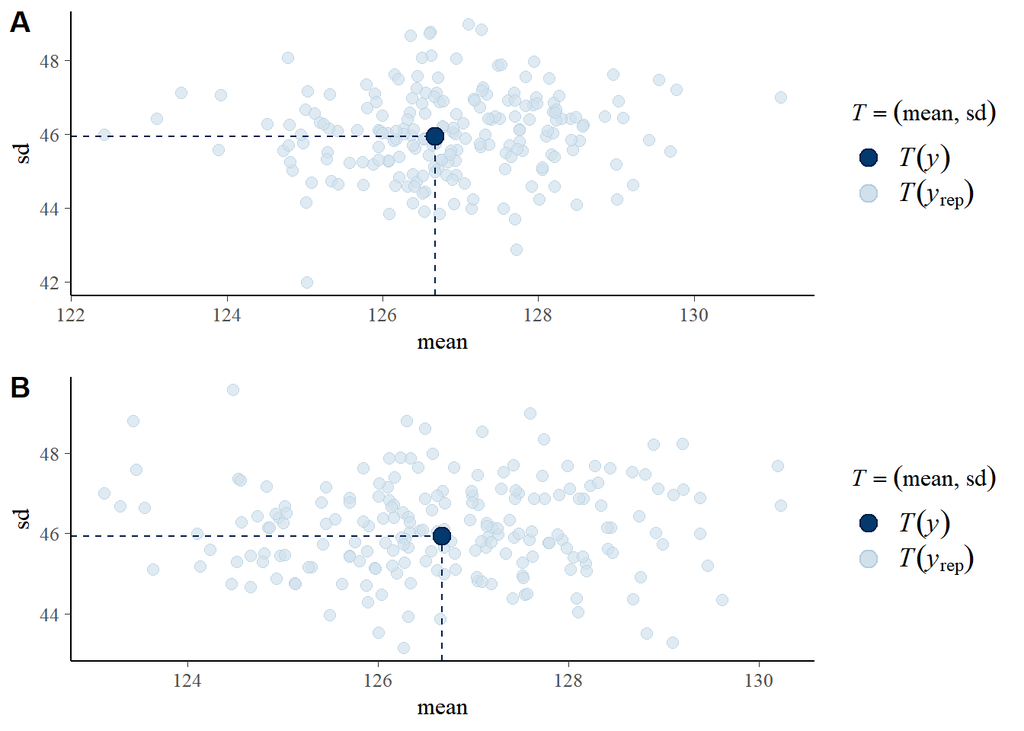

```r
pla<-pp_check(model3,type="stat_2d", stat = c("mean", "sd"),ndraws=200)
plb<-pp_check(model4,type="stat_2d", stat = c("mean", "sd"),ndraws=200)
plot_grid(pla, plb, labels=c("A", "B"), ncol = 1, nrow = 2)
```

```r
### Are there too influential observations?
par(mfrow=c(1,2))
plot(loo(model3));loo(model3)
```

```
Computed from 12000 by 960 log-likelihood matrix

         Estimate   SE
elpd_loo  -4694.8 26.8
p_loo        74.0  4.1
looic      9389.6 53.6
------
Monte Carlo SE of elpd_loo is 0.1.

All Pareto k estimates are good (k < 0.5).
See help('pareto-k-diagnostic') for details.
```

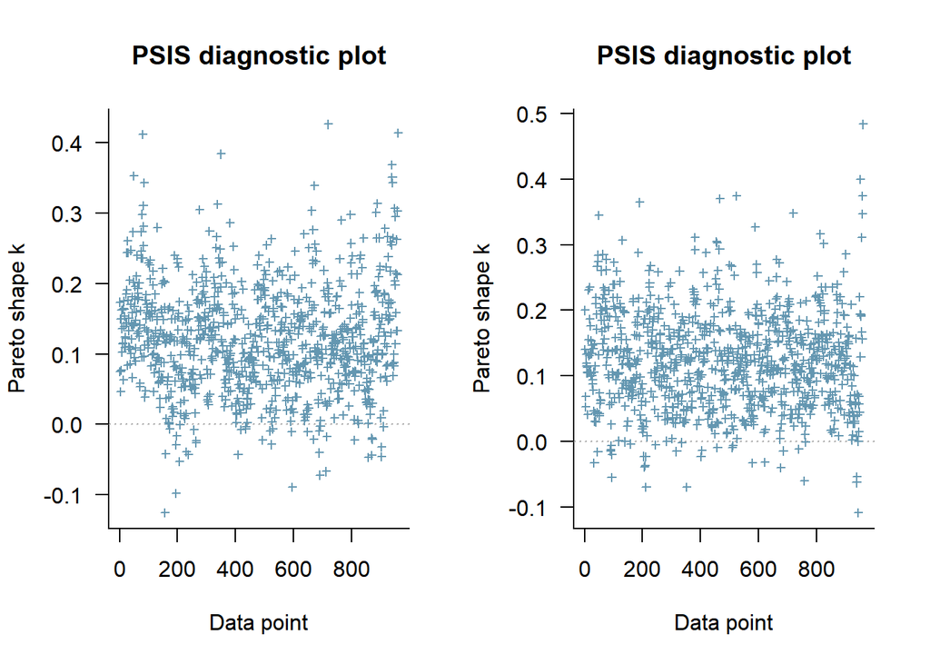

```
Computed from 12000 by 960 log-likelihood matrix

         Estimate   SE
elpd_loo  -4694.7 26.8
p_loo        73.5  4.1
looic      9389.5 53.6
------
Monte Carlo SE of elpd_loo is 0.1.

All Pareto k estimates are good (k < 0.5).
See help('pareto-k-diagnostic') for details.
```

```r
plot(loo(model4));loo(model4)
```

Everything seems fine.

## 4.8 Models comparison

Next, we will compare all three Gaussian models using LOO-CV

```r
model1 <- add_criterion(model1, criterion = "loo")
model3 <- add_criterion(model3, criterion = "loo")
model4 <- add_criterion(model4, criterion = "loo")

loo_compare(model1, model3, model4)
```

```
       elpd_diff se_diff
model1  0.0       0.0
model4 -0.5       0.6
model3 -0.5       1.1
```

Using baseline rotarod latency, averaged from all pre-treatment rotarod sessions, is comparable to using covariate from specifically 3rd or 2nd + 3rd day.

The model we currently have is, however, relatively simple. Likely the most importantly, it does not allow modelling the situation when group differ in day-to-day gain (implying motor learning).

Thus, let to create another model, which looks like *model1* but also include interaction between *group* and effect of *time*

## 4.9 Model including *group : day* interaction

```r
## fitting model
model5 <- run_model(
          brm(rot_latency ~ 0 + Intercept + mean_lat.x + session_cen +
              day_cen + session_cen:day_cen + group + day_cen:group + (1|id),
              family=gaussian(),
              data = rot_post_co,
              prior= prior01,
              save_pars = save_pars(all = TRUE),
              iter=8000, warmup=2000,chains=2,cores=1,seed=17,
              control = list(adapt_delta = 0.99, max_treedepth = 15)),
              'output/brm/model5', reuse = TRUE)

## model summary
summary(model5)
```

```
 Family: gaussian
  Links: mu = identity; sigma = identity
Formula: rot_latency ~ 0 + Intercept + mean_lat.x + session_cen + day_cen + session_cen:day_cen + group + day_cen:group + (1 | id)
   Data: rot_post_co (Number of observations: 960)
  Draws: 2 chains, each with iter = 8000; warmup = 2000; thin = 1;
         total post-warmup draws = 12000

Group-Level Effects:
~id (Number of levels: 80)
              Estimate Est.Error l-95% CI u-95% CI Rhat Bulk_ESS Tail_ESS
sd(Intercept)    24.24      2.30    20.01    29.09 1.00     2994     4963

Population-Level Effects:
                     Estimate Est.Error l-95% CI u-95% CI Rhat Bulk_ESS
Intercept               39.08     13.91    11.61    66.22 1.00     1919
mean_lat.x               0.56      0.11     0.36     0.77 1.00     1954
session_cen              5.90      0.90     4.16     7.63 1.00    13428
day_cen                  3.66      2.40    -1.02     8.35 1.00     4552
groupctrl.wt            29.77      8.20    13.69    45.72 1.00     1876
groupeda.wt             27.86      8.40    11.12    44.26 1.00     1603
groupeda.sca             3.42      8.10   -12.55    19.03 1.00     1815
session_cen:day_cen     -0.27      0.95    -2.17     1.59 1.00    15380
day_cen:groupctrl.wt    13.32      3.40     6.60    19.90 1.00     5779
day_cen:groupeda.wt      4.96      3.42    -1.73    11.68 1.00     5807
day_cen:groupeda.sca     3.01      3.38    -3.59     9.48 1.00     6298
                     Tail_ESS
Intercept                3810
mean_lat.x               3990
session_cen              9003
day_cen                  6931
groupctrl.wt             3583
groupeda.wt              3157
groupeda.sca             3156
session_cen:day_cen      8538
day_cen:groupctrl.wt     7919
day_cen:groupeda.wt      7749
day_cen:groupeda.sca     8316

Family Specific Parameters:
      Estimate Est.Error l-95% CI u-95% CI Rhat Bulk_ESS Tail_ESS
sigma    30.65      0.74    29.26    32.15 1.00    11851     8434

Draws were sampled using sampling(NUTS). For each parameter, Bulk_ESS
and Tail_ESS are effective sample size measures, and Rhat is the potential
scale reduction factor on split chains (at convergence, Rhat = 1).
```

```r
## prior summary
prior_summary(model5)
```

```
                  prior class                 coef group resp dpar nlpar lb ub
                 (flat)     b
          normal(10,20)     b              day_cen
                 (flat)     b day_cen:groupctrl.wt
                 (flat)     b day_cen:groupeda.sca
                 (flat)     b  day_cen:groupeda.wt
           normal(0,92)     b         groupctrl.wt
           normal(0,46)     b         groupeda.sca
           normal(0,92)     b          groupeda.wt
 student_t(3, 127, 229)     b            Intercept
          normal(0.5,2)     b           mean_lat.x
           normal(0,20)     b          session_cen
            normal(0,2)     b  session_cen:day_cen
  student_t(3, 0, 45.3)    sd                                             0
  student_t(3, 0, 45.3)    sd                         id                  0
  student_t(3, 0, 45.3)    sd            Intercept    id                  0
  student_t(3, 0, 45.3) sigma                                             0
       source
      default
         user
 (vectorized)
 (vectorized)
 (vectorized)
         user
         user
         user
         user
         user
         user
         user
      default
 (vectorized)
 (vectorized)
      default
```

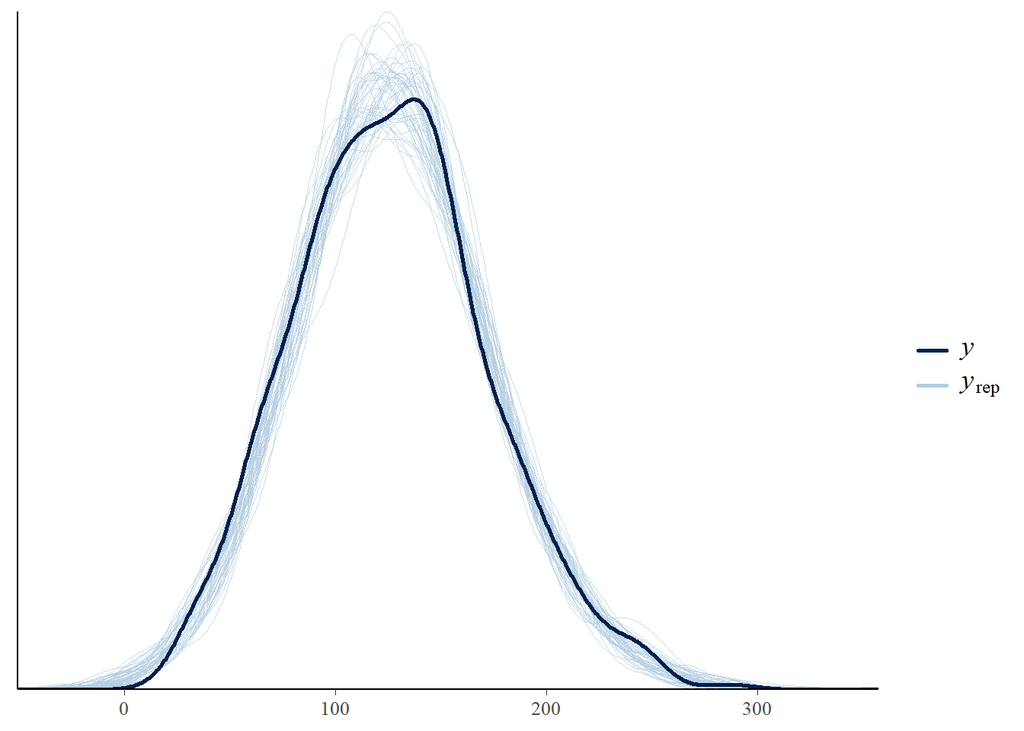

```r
## PPC
pp_check(model5,type='dens_overlay',ndraws = 50)
```

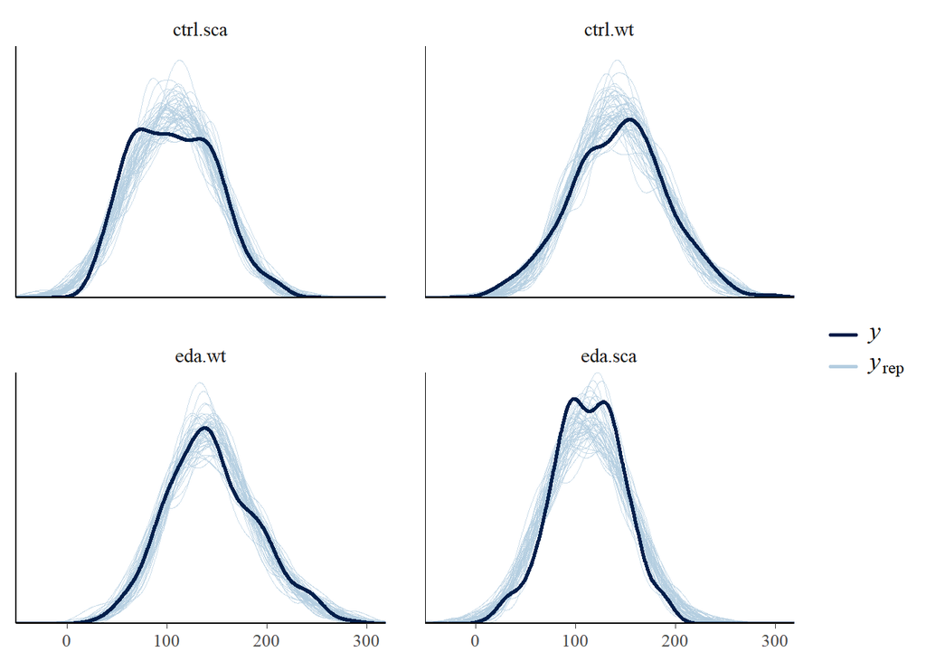

```r
pp_check(model5,type='dens_overlay_grouped',ndraws = 50,group='group')
```

```
Using all posterior draws for ppc type 'scatter_avg' by default.
```

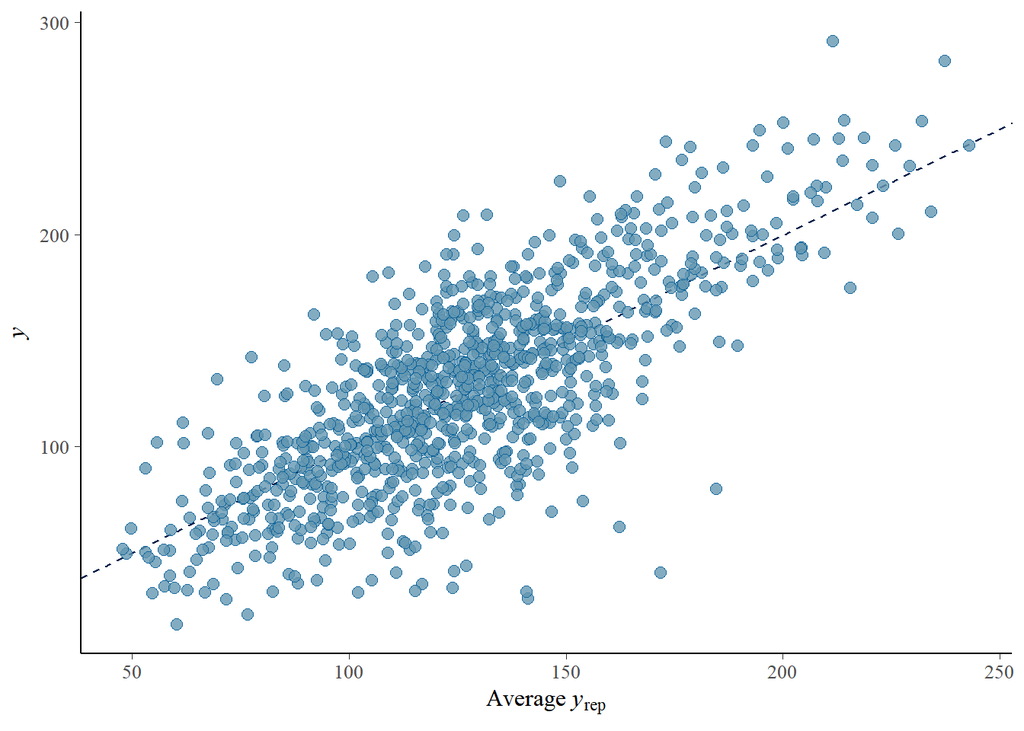

```r
pp_check(model5,type='scatter_avg')
```

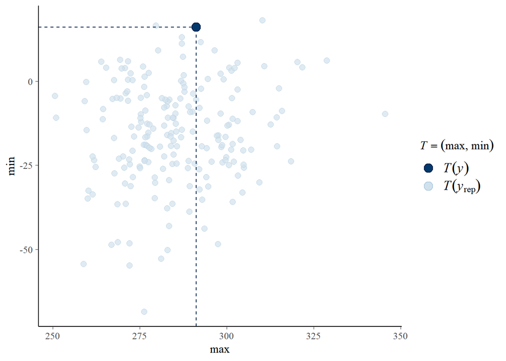

```r
pp_check(model5,type="stat_2d", stat = c("max", "min"),ndraws=200)
```

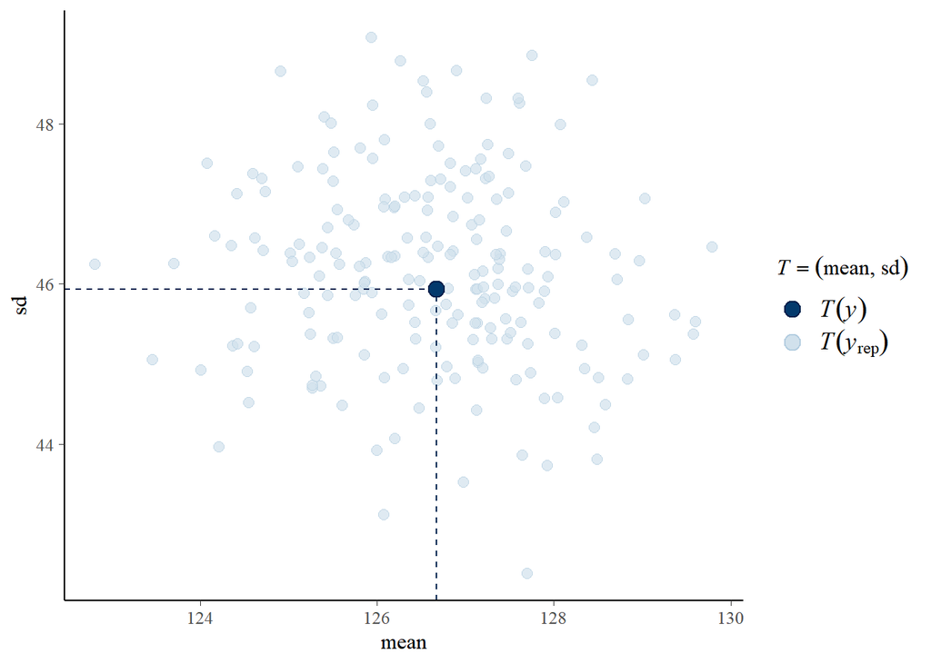

```r
pp_check(model5,type="stat_2d", stat = c("mean", "sd"),ndraws=200)
```

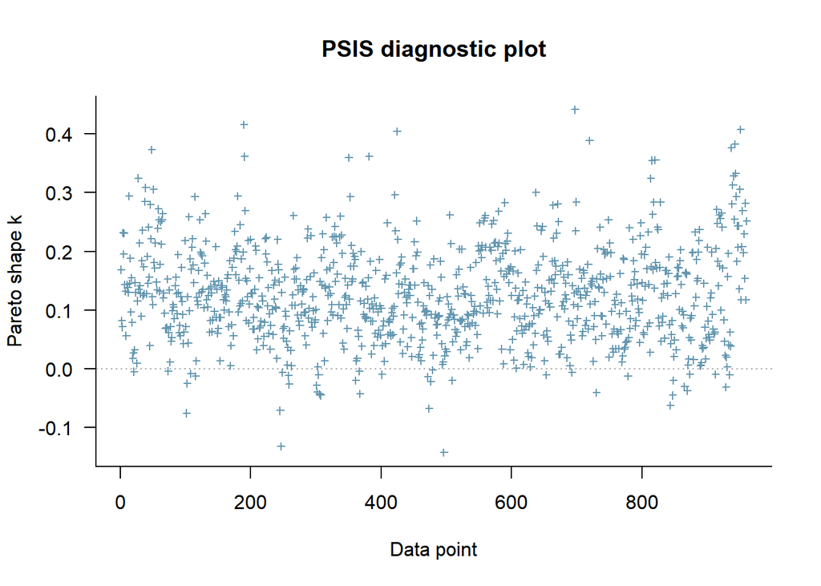

```
Computed from 12000 by 960 log-likelihood matrix

         Estimate   SE
elpd_loo  -4688.7 26.3
p_loo        76.3  4.1
looic      9377.3 52.6
------
Monte Carlo SE of elpd_loo is 0.1.

All Pareto k estimates are good (k < 0.5).
See help('pareto-k-diagnostic') for details.
```

```r
## Are there too influential observations?

plot(loo(model5));loo(model5)
```

```r
## comparing with original model via LOO-CV
model5 <- add_criterion(model5, criterion = "loo")
loo_compare(model1, model5)
```

```
       elpd_diff se_diff
model5  0.0       0.0
model1 -5.6       4.8
```

Models comparison indicate that more complex model, allowing group-specific change in rotarod performance over day, has better predictive accuracy. The last complex model (Gaussian distribution, ignoring sex, including *day* : *group* interaction) thus will be used as the final model.

The model coverged well, ESSs are sufficient, PPC seems fine.

## 4.10 Posterior draws extraction

```r
post_fix<-as.data.frame(model5, variable = c("b_Intercept","b_groupctrl.wt",
                                                       "b_groupeda.wt","b_groupeda.sca"))
names(post_fix)[1]<-"sca_ctrl"

post_fix$wt_ctrl<-post_fix$sca_ctrl+post_fix$b_groupctrl.wt
post_fix$wt_eda<-post_fix$sca_ctrl+post_fix$b_groupeda.wt
post_fix$sca_eda<-post_fix$sca_ctrl+post_fix$b_groupeda.sca
post_fix$wt_contrast<-post_fix$wt_eda-post_fix$wt_ctrl
summary(post_fix)
```

```
    sca_ctrl      b_groupctrl.wt    b_groupeda.wt    b_groupeda.sca
 Min.   :-16.00   Min.   : 0.5698   Min.   :-5.929   Min.   :-28.281
 1st Qu.: 29.81   1st Qu.:24.2420   1st Qu.:22.191   1st Qu.: -2.051
 Median : 39.13   Median :29.8007   Median :27.892   Median :  3.351
 Mean   : 39.08   Mean   :29.7691   Mean   :27.858   Mean   :  3.416
 3rd Qu.: 48.53   3rd Qu.:35.2160   3rd Qu.:33.536   3rd Qu.:  9.024
 Max.   : 91.93   Max.   :66.4481   Max.   :62.362   Max.   : 33.938
    wt_ctrl           wt_eda           sca_eda        wt_contrast
 Min.   :  9.15   Min.   :  2.729   Min.   :-14.06   Min.   :-40.123
 1st Qu.: 58.85   1st Qu.: 56.104   1st Qu.: 32.93   1st Qu.: -7.248
 Median : 69.06   Median : 67.066   Median : 42.76   Median : -1.859
 Mean   : 68.85   Mean   : 66.939   Mean   : 42.50   Mean   : -1.911
 3rd Qu.: 78.94   3rd Qu.: 77.698   3rd Qu.: 52.27   3rd Qu.:  3.473
 Max.   :126.46   Max.   :124.232   Max.   :103.39   Max.   : 30.281
```

```r
groupquant<-sapply(post_fix[,c(5,6,1,7)],function(p) quantile(p, probs = c(0.025,0.975,0.5)))
groupquant <- groupquant
```

# 5 Data visualisation

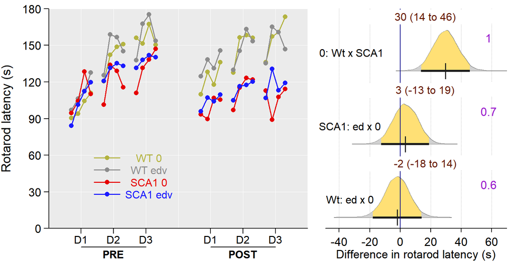

```r
rot_post_co$group <- factor(rot_post_co$group,levels = c('ctrl.wt','eda.wt','ctrl.sca','eda.sca') )

m= matrix(c(1,2), nrow = 1, ncol=2, byrow = TRUE)
layout(mat = m, heights = c(1),
       widths = c(0.65, 0.4))

par(mar=c(2,3,0,0))
par(mgp=c(2,0.6,0))
range<-c(0, 180);scal<-range[2]-range[1]
xrange<-c(0.5,4.5);xscal=xrange[2]-xrange[1]
plot(NULL,xlim=c(xrange[1],xrange[2]),ylim=c(range[1],range[2]),xlab="",
     ylab="Rotarod latency (s)",las=1, axes=FALSE,cex.lab=1.2)

rect(xrange[1],range[2],xrange[2],range[1],col="grey92",border=NA)
x<-range[1]
repeat{
  lines(c(xrange[1],xrange[2]),c(x,x),col="white",lwd=0.7)
  x=x+30;if(x>range[2]){break}}

x<-0.5
repeat{
  lines(c(x,x),c(range[1],range[2]),col="white",lwd=0.7)
  x=x+0.5;if(x>4.5){break}}


subdat <- subset(rotarod, pre_post == 'pre' & day == 1)
preD1 <- tapply(subdat$rot_latency, list(subdat$group, subdat$session), mean)
subdat <- subset(rotarod, pre_post == 'pre' & day == 2)
preD2 <- tapply(subdat$rot_latency, list(subdat$group, subdat$session), mean)
subdat <- subset(rotarod, pre_post == 'pre' & day == 3)
preD3 <- tapply(subdat$rot_latency, list(subdat$group, subdat$session), mean)


subdat <- subset(rotarod, pre_post == 'post' & day == 1)
postD1 <- tapply(subdat$rot_latency, list(subdat$group, subdat$session), mean)
subdat <- subset(rotarod, pre_post == 'post' & day == 2)
postD2 <- tapply(subdat$rot_latency, list(subdat$group, subdat$session), mean)
subdat <- subset(rotarod, pre_post == 'post' & day == 3)
postD3 <- tapply(subdat$rot_latency, list(subdat$group, subdat$session), mean)

xl <- c(0.85, 0.95, 1.05, 1.15)

for (x in 1:4){
lines(preD1[x,]~c(xl),col=cola[x], lwd = 1.6, type = 'o', pch= 16)
lines(preD2[x,]~c(xl+0.5),col= cola[x], lwd = 1.6, type = 'o', pch= 16)
lines(preD3[x,]~c(xl+1),col= cola[x], lwd = 1.6,, type = 'o', pch= 16)
lines(postD1[x,]~c(xl+2),col= cola[x], lwd = 1.6, type = 'o', pch= 16)
lines(postD2[x,]~c(xl+2.5),col= cola[x], lwd = 1.6, type = 'o', pch= 16)
lines(postD3[x,]~c(xl+3),col= cola[x], lwd = 1.6, type = 'o', pch= 16)
}

tckk=-0.02

axis(2,las=2,cex.axis=1.1,at=seq(range[1],range[2],by=30),pos=xrange[1],tck=tckk)

axis(side=1,las=1,cex.axis=1.1,at=c(1,1.5,2,3,3.5,4),
     labels=c(rep("",6)),pos=range[1],tck=tckk)
lines(c(0.5,4.5), c(0,0))
text(c(1, 1.5, 2, 3, 3.5, 4) ,c(rep(range[1]-0.05*scal)),
     c('D1', 'D2', 'D3', 'D1', 'D2', 'D3'), xpd= TRUE)

text(c(1.5, 3.5),c(range[1]-0.117*scal, range[1]-0.117*scal),
     c('PRE', 'POST'), font = 2, xpd = TRUE)
lines(c(1,2),c(range[1]-0.085*scal, range[1]-0.085*scal), xpd = TRUE)
lines(c(3,4),c(range[1]-0.085*scal, range[1]-0.085*scal), xpd = TRUE)

x = 1
y = 58;yde <- 10
lines(c(1.2,1.6),c(y,y), col = cola[x], pch = 16, lwd = 1.6)
text(2.05, y, 'WT 0', col = cola[x])
points(1.4, y, pch = 16, col = cola[x]); x = x+1; y = y-yde

lines(c(1.2,1.6),c(y,y), col = cola[x], pch = 16, lwd = 1.6)
text(2.05, y, 'WT edv', col = cola[x])
points(1.4, y, pch = 16, col = cola[x]); x = x+1; y = y-yde

lines(c(1.2,1.6),c(y,y), col = cola[x], pch = 16, lwd = 1.6)
text(2.05, y, 'SCA1 0', col = cola[x])
points(1.4, y, pch = 16, col = cola[x]); x = x+1; y = y-yde

lines(c(1.2,1.6),c(y,y), col = cola[x], pch = 16, lwd = 1.6)
text(2.05, y, 'SCA1 edv', col = cola[x])
points(1.4, y, pch = 16, col = cola[x]); x = x+1; y = y-yde

## probability distributions
par(mar=c(2,0,0,0))
dif<-data.frame(post_fix$wt_contrast,post_fix$b_groupeda.sca,
                post_fix$b_groupctrl.wt)
dif<-(dif)

yla<-"Difference in rotarod latency (s)"
tckk=-0.018
ste<-seq(-40,60,by=20)
mons_poste(dif, 0)

zpos=seq(0,1,1/3)
xx=1;ind=0.4;xpol<- -32
text(xpol,zpos[xx]+zpos[2]*ind,
     "Wt: ed x 0 ",cex=1)
xx=xx+1

text(xpol,zpos[xx]+zpos[2]*ind,
     "SCA1: ed x 0 ",cex=1)
xx=xx+1

text(xpol,zpos[xx]+zpos[2]*ind,
     "0: Wt x SCA1",cex=1)
```